# Assignment 3 Task 2

Jessica Jagdeo

3/19/2020

For Task 2, use text mining and analysis to explore a document of your choosing. Some ideas:

● There are many books with text publicly available (e.g. Silent Spring ) through the Internet Archive (you can find tons of options here, download either as PDF or get a .txt file) ● You can get all the text from Harry Potter books to analyze by book, chapter, etc. ● You can copy and paste text (e.g. from transcripts, reports, etc.) and read in as a txt file

Create a single knitted HTML that introduces the document, describes the goals of your analyses, shows your beautifully organized code + nice analyses + finalized data visualizations, and briefly describes some of your findings. Some questions might be:

- What (non-stop) words are most common in the document?
- How many words are associated with each sentiment?
- How does sentiment analysis compare for the different lexicons?
- How many times do words of interest to you appear in the text?
- How do sentiment/top words compare for speeches/documents/etc. from two or more different groups, candidates, etc.?

#### 1. Load packages

```r
library(tidyverse)
library(here)
library(janitor)

# For text mining:

library(pdftools)
library(tidytext)
library(textdata)
library(ggwordcloud)
```

#### 2. Read in the data

```r
carib_path <- "epdf.pub_twentieth-century-caribbean-literature.pdf"

carib_text <- pdf_text(carib_path)
```

#### Get this into dataframe shape and do some wrangling:

- Split up pages into separate lines (using ‘’) using ‘stringr::str_split()’
- Unnest into regular columns using ‘tidyr::unnest()’
- Remove leading/trailing white space using ‘stringr::str_trim()’

```r
carib_df <- data.frame(carib_text) %>%
  mutate(text_full = str_split(carib_text, pattern = "\r\n")) %>%
  unnest(text_full) %>%
  mutate(text_full = str_trim(text_full))
```

#### Get tokens using ‘unnest_tokens()’

```r
carib_tokens <- carib_df %>%
  unnest_tokens(word, text_full)
```

#### Count all the words:

```r
carib_wc <- carib_tokens %>%
  count(word) %>%
  arrange(-n)
```

#### Remove the stop words:

```r
carib_stop <- carib_tokens %>%
  anti_join(stop_words) %>%
  dplyr::select(-carib_text)
```

#### Remove all the numeric pieces:

```r
carib_no_numeric <- carib_stop %>%
  dplyr::filter(is.na(as.numeric(word))) # Convert all entries to numeric. If the entry is not a numeric, it returns 'NA'. If an entry is 'NA', retain it through the filter.
```

#### Start doing some visualization:

Word cloud

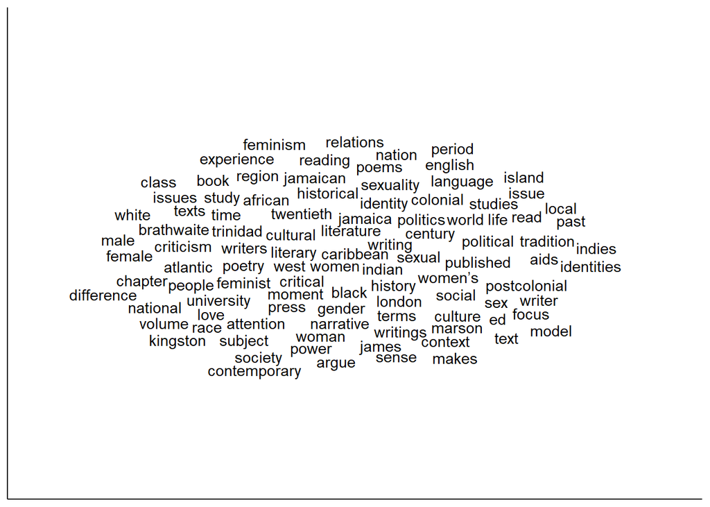

```r
carib_top100 <- carib_no_numeric %>%
  count(word) %>%
  arrange(-n) %>%
  head(100)

carib_cloud <- ggplot(carib_top100, aes(label = word)) +
  geom_text_wordcloud() +
  theme_classic()

carib_cloud
```

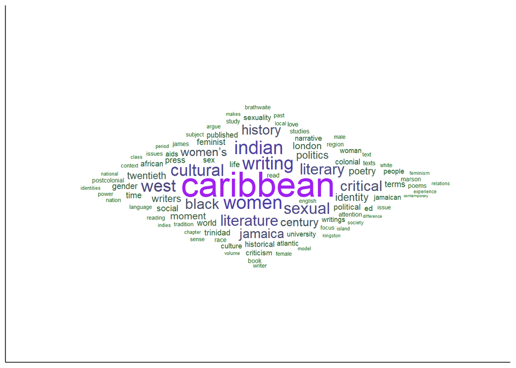

```r
ggplot(carib_top100, aes(label = word, size = n)) +
  geom_text_wordcloud_area(aes(color = n), shape = "diamond") +
  scale_size_area(max_size = 12) +
  scale_color_gradientn(colors = c("darkgreen", "blue", "purple")) +
  theme_classic()
```